# Accessing stock data with R

Richard Warnung

August 12, 2022

# Introduction

This is a short introduction to the [R package yfR](https://ropensci.org/blog/2022/07/26/package-yfr/) Required packages: yfr, lubridate, dplyr, ggplot2

# Installation

```r
# CRAN (stable)
install.packages('yfR')

# GitHub (dev version)
devtools::install_github('ropensci/yfR')

# rOpenSci
install.packages("yfR", repos = c("https://ropensci.r-universe.dev", "https://cloud.r-project.org"))
```

# From the vignette

## Retrieve historical data of S&P 500

```r
pacman::p_load(yfR, lubridate, dplyr)

# set options for algorithm
my_ticker = '^GSPC'
first_date = "1950-01-01"
last_date = Sys.Date()

# fetch data
df_yf = yf_get(tickers = my_ticker,
                first_date = first_date,
                last_date = last_date)
```

```
## -- Running yfR for 1 stocks | 1950-01-01 --> 2022-08-20 (26529 days) --
```

```
## i Downloading data for benchmark ticker ^GSPC
```

```
## i (1/1) Fetching data for ^GSPC
```

```
## √    - found cache file (1950-01-03 --> 2022-08-19)
```

```
## √    - got 18277 valid rows (1950-01-03 --> 2022-08-19)
```

```
## √    - got 100% of valid prices -- Time for some tea?
```

```
## i Binding price data
```

```
## -- Diagnostics -----------------------------------------------------------------------------------------------------------------------------------------------------
```

```
## √ Returned dataframe with 18277 rows -- You got it !
```

```
## i Using 1.9 MB at C:\Users\rwarn\AppData\Local\Temp\RtmpkplIrO/yf_cache for 1 cache files
```

```
## i Out of 1 requested tickers, you got 1 (100%)
```

```r
# output is a tibble with data
glimpse(df_yf)
```

```
## Rows: 18,277
## Columns: 11
## $ ticker                 <chr> "^GSPC", "^GSPC", "^GSPC", "^GSPC", "^GSPC", "^GSPC", "^GSPC", "^GSPC", "^GSPC", "^GSPC", "^GSPC", "^GSPC", "^GSPC", "^GSPC", "^GSP~
## $ ref_date               <date> 1950-01-03, 1950-01-04, 1950-01-05, 1950-01-06, 1950-01-09, 1950-01-10, 1950-01-11, 1950-01-12, 1950-01-13, 1950-01-16, 1950-01-17~
## $ price_open             <dbl> 16.66, 16.85, 16.93, 16.98, 17.08, 17.03, 17.09, 16.76, 16.67, 16.72, 16.86, 16.85, 16.87, 16.90, 16.92, 16.86, 16.74, 16.73, 16.82~
## $ price_high             <dbl> 16.66, 16.85, 16.93, 16.98, 17.08, 17.03, 17.09, 16.76, 16.67, 16.72, 16.86, 16.85, 16.87, 16.90, 16.92, 16.86, 16.74, 16.73, 16.82~
## $ price_low              <dbl> 16.66, 16.85, 16.93, 16.98, 17.08, 17.03, 17.09, 16.76, 16.67, 16.72, 16.86, 16.85, 16.87, 16.90, 16.92, 16.86, 16.74, 16.73, 16.82~
## $ price_close            <dbl> 16.66, 16.85, 16.93, 16.98, 17.08, 17.03, 17.09, 16.76, 16.67, 16.72, 16.86, 16.85, 16.87, 16.90, 16.92, 16.86, 16.74, 16.73, 16.82~
## $ volume                 <dbl> 1260000, 1890000, 2550000, 2010000, 2520000, 2160000, 2630000, 2970000, 3330000, 1460000, 1790000, 1570000, 1170000, 1440000, 13400~
## $ price_adjusted         <dbl> 16.66, 16.85, 16.93, 16.98, 17.08, 17.03, 17.09, 16.76, 16.67, 16.72, 16.86, 16.85, 16.87, 16.90, 16.92, 16.86, 16.74, 16.73, 16.82~
## $ ret_adjusted_prices    <dbl> NA, 0.0114045618, 0.0047477745, 0.0029533373, 0.0058892815, -0.0029273419, 0.0035231354, -0.0193095377, -0.0053699284, 0.0029993401~
## $ ret_closing_prices     <dbl> NA, 0.0114045618, 0.0047477745, 0.0029533373, 0.0058892815, -0.0029273419, 0.0035231354, -0.0193095377, -0.0053699284, 0.0029993401~
## $ cumret_adjusted_prices <dbl> 1.000000, 1.011405, 1.016206, 1.019208, 1.025210, 1.022209, 1.025810, 1.006002, 1.000600, 1.003601, 1.012005, 1.011405, 1.012605, 1~
```

The total return can be calculated based on the the adjusted price

```r
n_years = interval(min(df_yf$ref_date), max(df_yf$ref_date))/years(1)

total_return = last(df_yf$price_adjusted)/first(df_yf$price_adjusted) - 1

cat(paste0("n_years = ", n_years, "\n",
           "total_return = ", total_return))
```

```
## n_years = 72.6246575342466
## total_return = 252.810322929172
```

```r
## check
last(df_yf$cumret_adjusted_prices)
```

```
## [1] 253.8103
```

Additionally, we can calculate the average annual return

```r
ret_comp <- (1 + total_return)^(1/n_years)  - 1

cat(paste0("Comp Return = ",
           scales::percent(ret_comp, accuracy = 0.01)))
```

```
## Comp Return = 7.92%
```

```r
## checking:
(1+ret_comp)^n_years - 1
```

```
## [1] 252.8103
```

We can plot the performance like that:

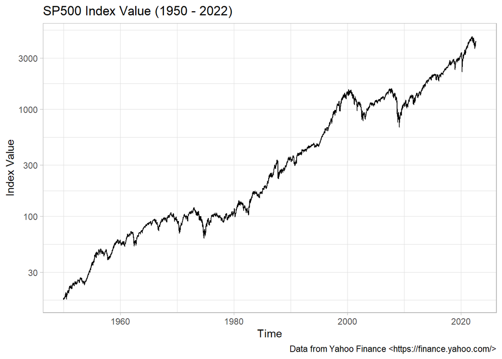

```r
library(ggplot2)

p <- ggplot(df_yf, aes(x = ref_date, y = price_adjusted)) +
  geom_line() +
  labs(
    title = paste0("SP500 Index Value (",
                   year(min(df_yf$ref_date)), ' - ',
                   year(max(df_yf$ref_date)), ")"
    ),
    x = "Time",
    y = "Index Value",
    caption = "Data from Yahoo Finance <https://finance.yahoo.com/>") +
  theme_light() +
  scale_y_log10()

p
```

## Analyze many stocks

We can analyze many stocks by observing the index composition. To this aim, we sample 10 stocks from the current compoisition of the S&P 500.

```r
set.seed(20220713)

n_tickers <- 10
df_sp500 <- yf_index_composition("SP500")
```

```
## √ Got SP500 composition with 503 rows
```

```r
rnd_tickers <- sample(df_sp500$ticker, n_tickers)

cat(paste0("The selected tickers are: ", paste0(rnd_tickers, collapse = ", ")))
```

```
## The selected tickers are: AAPL, DHI, AMZN, CMS, FCX, NRG, EXR, CFG, CI, AWK
```

Next we fetch all prices

```r
df_yf <- yf_get(tickers = rnd_tickers,
                first_date = '2010-01-01',
                last_date = Sys.Date())
```

```
## -- Running yfR for 10 stocks | 2010-01-01 --> 2022-08-20 (4614 days) --
```

```
## i Downloading data for benchmark ticker ^GSPC
```

```
## i (1/10) Fetching data for AAPL
```

```
## !    - not cached
```

```
## √    - cache saved successfully
```

```
## √    - got 3180 valid rows (2010-01-04 --> 2022-08-19)
```

```
## √    - got 100% of valid prices -- Looking good!
```

```
## i (2/10) Fetching data for DHI
```

```
## !    - not cached
```

```
## √    - cache saved successfully
```

```
## √    - got 3180 valid rows (2010-01-04 --> 2022-08-19)
```

```
## √    - got 100% of valid prices -- Well done !
```

```
## i (3/10) Fetching data for AMZN
```

```
## !    - not cached
```

```
## √    - cache saved successfully
```

```
## √    - got 3180 valid rows (2010-01-04 --> 2022-08-19)
```

```
## √    - got 100% of valid prices -- Youre doing good!
```

```
## i (4/10) Fetching data for CMS
```

```
## !    - not cached
```

```
## √    - cache saved successfully
```

```
## √    - got 3180 valid rows (2010-01-04 --> 2022-08-19)
```

```
## √    - got 100% of valid prices -- Well done !
```

```
## i (5/10) Fetching data for FCX
```

```
## !    - not cached
```

```
## √    - cache saved successfully
```

```
## √    - got 3180 valid rows (2010-01-04 --> 2022-08-19)
```

```
## √    - got 100% of valid prices -- Looking good!
```

```
## i (6/10) Fetching data for NRG
```

```
## !    - not cached
```

```
## √    - cache saved successfully
```

```
## √    - got 3180 valid rows (2010-01-04 --> 2022-08-19)
```

```
## √    - got 100% of valid prices -- Got it!
```

```
## i (7/10) Fetching data for EXR
```

```
## !    - not cached
```

```
## √    - cache saved successfully
```

```
## √    - got 3180 valid rows (2010-01-04 --> 2022-08-19)
```

```
## √    - got 100% of valid prices -- Good stuff!
```

```
## i (8/10) Fetching data for CFG
```

```
## !    - not cached
```

```
## √    - cache saved successfully
```

```
## x    - **REMOVED** found only 63% of valid prices (thresh_bad_data = 75%)
```

```
## i (9/10) Fetching data for CI
```

```
## !    - not cached
```

```
## √    - cache saved successfully
```

```
## √    - got 3180 valid rows (2010-01-04 --> 2022-08-19)
```

```
## √    - got 100% of valid prices -- Got it!
```

```
## i (10/10) Fetching data for AWK
```

```
## !    - not cached
```

```
## √    - cache saved successfully
```

```
## √    - got 3180 valid rows (2010-01-04 --> 2022-08-19)
```

```
## √    - got 100% of valid prices -- Nice!
```

```
## i Binding price data
```

```
## -- Diagnostics -----------------------------------------------------------------------------------------------------------------------------------------------------
```

```
## √ Returned dataframe with 28620 rows -- Got it!
```

```
## i Using 4.9 MB at C:\Users\rwarn\AppData\Local\Temp\RtmpkplIrO/yf_cache for 1 cache files
```

```
## i Out of 10 requested tickers, you got 9 (90%)
```

One stock was removed as it was not possible to fetch sufficiently many prices. We plot the remaining ones as follows:

[figure not shown]

```r
p <- ggplot(df_yf,
            aes(x = ref_date,
                y = cumret_adjusted_prices,
                color = ticker)) +
  geom_line() +
  labs(
    title = paste0("SP500 Index Value (",
                   year(min(df_yf$ref_date)), ' - ',
                   year(max(df_yf$ref_date)), ")"
    ),
    x = "Time",
    y = "Accumulated Return (from 100%)",
    caption = "Data from Yahoo Finance <https://finance.yahoo.com/>") +
  theme_light() +
  scale_y_log10()

p
```

Finally, we produce an overview table with the previous return measurements:

```r
library(dplyr)

tab_perf <- df_yf |>
  group_by(ticker) |>
  summarise(
    n_years = interval(min(ref_date),
                       max(ref_date))/years(1),
    total_ret = last(price_adjusted)/first(price_adjusted) - 1,
    ret_comp = (1 + total_ret)^(1/n_years) - 1
  )

tab_perf |>
  mutate(n_years = floor(n_years),
         total_ret = scales::percent(total_ret),
         ret_comp = scales::percent(ret_comp)) |>
  knitr::kable(caption = "Financial Performance of Several Stocks")
```

Financial Performance of Several Stocks

| ticker | n_years | total_ret | ret_comp |
| --- | --- | --- | --- |
| AAPL | 12 | 2 528% | 29.56% |
| AMZN | 12 | 1 965% | 27.11% |
| AWK | 12 | 836% | 19.39% |
| CI | 12 | 732% | 18.28% |
| CMS | 12 | 585% | 16.47% |
| DHI | 12 | 667% | 17.51% |
| EXR | 12 | 2 573% | 29.73% |
| FCX | 12 | -3% | -0.26% |
| NRG | 12 | 120% | 6.46% |

## Query many tickers with quantmod

taken from [this blog post](https://kiandlee.blogspot.com/2022/08/r-code-snippet-read-historical-prices_14.html).

```r
#========================================================#
# Quantitative ALM, Financial Econometrics & Derivatives
# ML/DL using R, Python, Tensorflow by Sang-Heon Lee
#
# https://kiandlee.blogspot.com
```

```r
# read historical prices of stock indices
#========================================================#

library(quantmod)
library(stringr) # trim
```

```r
# Symbols of stock indices, as of 2022-08-14
```

```r
vstr_symbol <- "
    Symbol    ,    Name
    ^GSPC     ,    S&P 500
    ^DJI      ,    Dow 30
    ^IXIC     ,    Nasdaq
    ^NYA      ,    NYSE COMPOSITE (DJ)
    ^XAX      ,    NYSE AMEX COMPOSITE INDEX
    ^BUK100P  ,    Cboe UK 100
    ^RUT      ,    Russell 2000
    ^VIX      ,    CBOE Volatility Index
    ^FTSE     ,    FTSE 100
    ^GDAXI    ,    DAX PERFORMANCE-INDEX
    ^FCHI     ,    CAC 40
    ^STOXX50E ,    ESTX 50 PR.EUR
    ^N100     ,    Euronext 100 Index
    ^BFX      ,    BEL 20
    ^N225     ,    Nikkei 225
    ^HSI      ,    HANG SENG INDEX
    000001.SS ,    SSE Composite Index
    399001.SZ ,    Shenzhen Index
    ^STI      ,    STI Index
    ^AXJO     ,    S&P/ASX 200
    ^AORD     ,    ALL ORDINARIES
    ^BSESN    ,    S&P BSE SENSEX
    ^JKSE     ,    Jakarta Composite Index
    ^KLSE     ,    FTSE Bursa Malaysia KLCI
    ^NZ50     ,    S&P/NZX 50 INDEX GROSS
    ^KS11     ,    KOSPI Composite Index
    ^TWII     ,    TSEC weighted index
    ^GSPTSE   ,    S&P/TSX Composite index
    ^BVSP     ,    IBOVESPA
    ^MXX      ,    IPC MEXICO
    ^TA125.TA ,    TA-125
    ^JN0U.JO  ,    Top 40 USD Net TRI Index
    "
```

```r
# split symbols and make vector
```

```r
df <- read.table(text = str_trim(vstr_symbol),
                 sep = ",", header = TRUE)
df <- as.data.frame(df); df
```

```
##            Symbol                             Name
## 1      ^GSPC                            S&P 500
## 2      ^DJI                                 Dow 30
## 3      ^IXIC                                Nasdaq
## 4      ^NYA                    NYSE COMPOSITE (DJ)
## 5      ^XAX           NYSE AMEX COMPOSITE INDEX
## 6      ^BUK100P                        Cboe UK 100
## 7      ^RUT                           Russell 2000
## 8      ^VIX                  CBOE Volatility Index
## 9      ^FTSE                              FTSE 100
## 10     ^GDAXI                DAX PERFORMANCE-INDEX
## 11     ^FCHI                                CAC 40
## 12     ^STOXX50E                    ESTX 50 PR.EUR
## 13     ^N100                    Euronext 100 Index
## 14     ^BFX                                 BEL 20
```

[output cut: 18 more lines]

```r
df$Symbol <- str_trim(gsub("[\t\r\n,]", "", df$Symbol))
df$Name   <- str_trim(gsub("[\t\r\n,]", "", df$Name))
df
```

```
##       Symbol                      Name
## 1      ^GSPC                   S&P 500
## 2       ^DJI                    Dow 30
## 3      ^IXIC                    Nasdaq
## 4       ^NYA       NYSE COMPOSITE (DJ)
## 5       ^XAX NYSE AMEX COMPOSITE INDEX
## 6   ^BUK100P               Cboe UK 100
## 7       ^RUT              Russell 2000
## 8       ^VIX     CBOE Volatility Index
## 9      ^FTSE                  FTSE 100
## 10    ^GDAXI     DAX PERFORMANCE-INDEX
## 11     ^FCHI                    CAC 40
## 12 ^STOXX50E            ESTX 50 PR.EUR
## 13     ^N100        Euronext 100 Index
## 14      ^BFX                    BEL 20
```

[output cut: 18 more lines]

```r
nc <- nrow(df) # number of index
```

```r
# read price information
```

```r
sdate <- as.Date("2016-01-01")
edate <- as.Date("2022-08-12")
getSymbols(df$Symbol, from=sdate, to=edate)
```

[output not shown]

[output not shown]

[output not shown]

[output not shown]

[output not shown]

[output not shown]

[output not shown]

[output not shown]

[output not shown]

[output not shown]

[output not shown]

[output not shown]

[output not shown]

[output not shown]

[output not shown]

[output not shown]

[output not shown]

[output not shown]

[output not shown]

[output not shown]

[output not shown]

```
##  [1] "^GSPC"     "^DJI"      "^IXIC"     "^NYA"      "^XAX"      "^BUK100P"  "^RUT"      "^VIX"      "^FTSE"     "^GDAXI"    "^FCHI"     "^STOXX50E" "^N100"
## [14] "^BFX"      "^N225"     "^HSI"      "000001.SS" "399001.SZ" "^STI"      "^AXJO"     "^AORD"     "^BSESN"    "^JKSE"     "^KLSE"     "^NZ50"     "^KS11"
## [27] "^TWII"     "^GSPTSE"   "^BVSP"     "^MXX"      "^TA125.TA" "^JN0U.JO"
```

```r
# collect only adjusted prices
```

```r
price <- NULL
for(i in 1:nc) {
  eval(parse(text=paste0(
    "price <- cbind(price,`",
    gsub("\\^","",df$Symbol[i]),"`[,6])")))
}

# modify column Name as only symbol
colnames(price) <- gsub(".Adjusted", "",
                        colnames(price))

# convert to data.frame with the first column as Date
df.price <- cbind(time=time(price), as.data.frame(price))
rownames(df.price) <- NULL

# partial selection of complete cases
# by S&P 500, Nikkei 225, HANG SENG INDEX
df.price <- df.price[complete.cases(
  df.price[,c("GSPC","N225","HSI")]),]
```

```r
# print time series of daily prices
```

```r
head(df.price,3)
```

```
##         time    GSPC      DJI    IXIC      NYA     XAX BUK100P     RUT   VIX   FTSE    GDAXI    FCHI STOXX50E   N100     BFX     N225      HSI X000001.SS
## 1 2016-01-04 2012.66 17148.94 4903.09 10001.56 2121.27  604.64 1108.62 20.70 6093.4 10283.44 4522.45  3164.76 885.00 3642.79 18450.98 21327.12   3296.258
## 2 2016-01-05 2016.71 17158.66 4891.43 10028.06 2125.25  608.78 1110.44 19.34 6137.2 10310.10 4537.63  3178.01 890.53 3653.18 18374.00 21188.72   3287.711
## 3 2016-01-06 1990.26 16906.51 4835.76  9868.26 2099.47  603.03 1094.37 20.59 6073.4 10214.02 4480.47  3139.32 879.27 3613.69 18191.32 20980.81   3361.840
##   X399001.SZ     STI   AXJO   AORD    BSESN     JKSE    KLSE    NZ50    KS11     TWII  GSPTSE  BVSP      MXX TA125.TA JN0U.JO
## 1   11625.91 2835.97 5270.5 5322.8 25623.35 4525.919 1653.37      NA 1918.76 8114.229 12927.2 42141 42113.70  1311.38      NA
## 2   11467.93 2834.23 5184.4 5239.2 25580.34 4557.822 1665.70 6278.10 1930.53 8075.079 12920.1 42419 42041.68  1321.16      NA
## 3   11724.75 2804.27 5123.1 5178.0 25406.33 4608.982 1667.97 6262.52 1925.43 7990.359 12726.8 41773 41691.19  1308.94      NA
```

```r
tail(df.price,3)
```

```
##            time    GSPC      DJI     IXIC      NYA     XAX BUK100P     RUT   VIX   FTSE    GDAXI    FCHI STOXX50E    N100     BFX     N225      HSI X000001.SS
## 2056 2022-08-08 4140.06 32832.54 12644.46 15305.80 3971.04  747.49 1941.21 21.29 7482.4 13687.69 6524.44  3757.22 1263.55 3798.91 28249.24 20045.77    3236.93
## 2057 2022-08-09 4122.47 32774.41 12493.93 15264.79 4004.73  747.80 1912.89 21.77 7488.2 13534.97 6490.00  3715.37 1254.72 3811.29 27999.96 20003.44    3247.43
## 2058 2022-08-10 4210.24 33309.51 12854.80 15552.70 4060.95  750.90 1969.25 19.74 7507.1 13700.93 6523.44  3749.35 1262.16 3837.90 27819.33 19610.84    3230.02
##      X399001.SZ     STI   AXJO   AORD    BSESN     JKSE    KLSE     NZ50    KS11     TWII  GSPTSE   BVSP      MXX TA125.TA JN0U.JO
## 2056   12302.15 3270.98 7020.6 7259.5 58853.07 7086.849 1496.03 11702.81 2493.10 15020.41 19669.2 108402 47354.86  2046.00 4134.29
## 2057   12331.09      NA 7029.8 7278.6       NA 7102.880 1497.68 11753.48 2503.46 15050.28 19578.3 108651 47241.81  2039.30      NA
## 2058   12223.51 3286.33 6992.7 7238.7 58817.29 7086.236 1492.33 11752.09 2480.88 14939.02 19885.9 110236 47808.21  2076.39 4207.89
```

## Query exchange rates using quantmod

taken from [this blog post](https://kiandlee.blogspot.com/2022/08/r-code-snippet-read-historical-daily.html).

```r
library(quantmod)
library(stringr) # trim
```

```r
# Symbols of exchange rates, as of 2022-08-14
```

```r
vstr_symbol <- "
    Symbol  ,    Name
    EURUSD=X,    EUR/USD
    JPY=X   ,    USD/JPY
    GBPUSD=X,    GBP/USD
    AUDUSD=X,    AUD/USD
    NZDUSD=X,    NZD/USD
    EURJPY=X,    EUR/JPY
    GBPJPY=X,    GBP/JPY
    EURGBP=X,    EUR/GBP
    EURCAD=X,    EUR/CAD
    EURSEK=X,    EUR/SEK
    EURCHF=X,    EUR/CHF
    EURHUF=X,    EUR/HUF
    CNY=X   ,    USD/CNY
    HKD=X   ,    USD/HKD
    SGD=X   ,    USD/SGD
    INR=X   ,    USD/INR
    MXN=X   ,    USD/MXN
    PHP=X   ,    USD/PHP
    IDR=X   ,    USD/IDR
    THB=X   ,    USD/THB
    MYR=X   ,    USD/MYR
    ZAR=X   ,    USD/ZAR
    RUB=X   ,    USD/RUB
    "
```

```r
# split symbols and make vector
```

```r
df <- read.table(text = str_trim(vstr_symbol),
                 sep = ",", header = TRUE)
df <- as.data.frame(df); df
```

```
##          Symbol           Name
## 1      EURUSD=X     EUR/USD
## 2      JPY=X         USD/JPY
## 3      GBPUSD=X        GBP/USD
## 4      AUDUSD=X        AUD/USD
## 5      NZDUSD=X        NZD/USD
## 6      EURJPY=X        EUR/JPY
## 7      GBPJPY=X        GBP/JPY
## 8      EURGBP=X        EUR/GBP
## 9      EURCAD=X        EUR/CAD
## 10     EURSEK=X        EUR/SEK
## 11     EURCHF=X        EUR/CHF
## 12     EURHUF=X        EUR/HUF
## 13     CNY=X           USD/CNY
## 14     HKD=X           USD/HKD
## 15     SGD=X           USD/SGD
## 16     INR=X           USD/INR
## 17     MXN=X           USD/MXN
## 18     PHP=X           USD/PHP
## 19     IDR=X           USD/IDR
## 20     THB=X           USD/THB
## 21     MYR=X           USD/MYR
## 22     ZAR=X           USD/ZAR
## 23     RUB=X           USD/RUB
```

```r
df$Symbol <- str_trim(gsub("[\t\r\n,]", "", df$Symbol))
df$Name   <- str_trim(gsub("[\t\r\n,]", "", df$Name))
df
```

```
##      Symbol    Name
## 1  EURUSD=X EUR/USD
## 2     JPY=X USD/JPY
## 3  GBPUSD=X GBP/USD
## 4  AUDUSD=X AUD/USD
## 5  NZDUSD=X NZD/USD
## 6  EURJPY=X EUR/JPY
## 7  GBPJPY=X GBP/JPY
## 8  EURGBP=X EUR/GBP
## 9  EURCAD=X EUR/CAD
## 10 EURSEK=X EUR/SEK
## 11 EURCHF=X EUR/CHF
## 12 EURHUF=X EUR/HUF
## 13    CNY=X USD/CNY
## 14    HKD=X USD/HKD
## 15    SGD=X USD/SGD
## 16    INR=X USD/INR
## 17    MXN=X USD/MXN
## 18    PHP=X USD/PHP
## 19    IDR=X USD/IDR
## 20    THB=X USD/THB
## 21    MYR=X USD/MYR
## 22    ZAR=X USD/ZAR
## 23    RUB=X USD/RUB
```

```r
nc <- nrow(df) # number of exchange rate
```

```r
# read price information
```

```r
sdate <- as.Date("2016-01-01")
edate <- as.Date("2022-07-31")
getSymbols(df$Symbol, from=sdate, to=edate)
```

[output not shown]

[output not shown]

[output not shown]

[output not shown]

[output not shown]

[output not shown]

[output not shown]

[output not shown]

[output not shown]

[output not shown]

[output not shown]

[output not shown]

[output not shown]

[output not shown]

[output not shown]

[output not shown]

[output not shown]

[output not shown]

[output not shown]

```
##  [1] "EURUSD=X" "JPY=X"    "GBPUSD=X" "AUDUSD=X" "NZDUSD=X" "EURJPY=X" "GBPJPY=X" "EURGBP=X" "EURCAD=X" "EURSEK=X" "EURCHF=X" "EURHUF=X" "CNY=X"    "HKD=X"
## [15] "SGD=X"    "INR=X"    "MXN=X"    "PHP=X"    "IDR=X"    "THB=X"    "MYR=X"    "ZAR=X"    "RUB=X"
```

```r
# collect only adjusted prices
```

```r
price <- NULL
for(i in 1:nc) {
  eval(parse(text=paste0(
    "price <- cbind(price,`",
    gsub("\\^","",df$Symbol[i]),"`[,6])")))
}

# modify column Name as only symbol
colnames(price) <- gsub(".X.Adjusted", "", colnames(price))

# convert to data.frame with the first column as Date
df.price <- cbind(time=time(price), as.data.frame(price))
rownames(df.price) <- NULL
```

```r
# print time series of daily prices
```

```r
head(df.price,3)
```

```
##         time   EURUSD     JPY   GBPUSD   AUDUSD   NZDUSD  EURJPY  GBPJPY  EURGBP  EURCAD  EURSEK  EURCHF  EURHUF    CNY     HKD     SGD    INR      MXN    PHP
## 1 2016-01-01 1.085906 120.288 1.473839 0.727167 0.684135 130.612 177.275 0.73673 1.50930 9.15667 1.08737 315.838 6.4837 7.75011 1.41928 66.193 17.26976 46.713
## 2 2016-01-04 1.085399 120.311 1.473709 0.728704 0.683293 130.576 177.268 0.73640 1.50460 9.15680 1.08470 314.530 6.4837 7.75037 1.41850 66.193 17.28818 46.762
## 3 2016-01-05 1.082755 119.467 1.471410 0.718597 0.674582 129.300 175.740 0.73560 1.50839 9.20058 1.08520 314.200 6.5254 7.75126 1.42602 66.601 17.32546 46.967
##     IDR    THB    MYR      ZAR     RUB
## 1 13775 35.421 4.3052 15.46000 73.2300
## 2 13775 35.436 4.3505 15.46064 73.4000
## 3 13957 36.127 4.3555 15.52300 73.1225
```

```r
tail(df.price,3)
```

```
##            time   EURUSD     JPY   GBPUSD   AUDUSD   NZDUSD  EURJPY  GBPJPY  EURGBP  EURCAD   EURSEK  EURCHF  EURHUF    CNY     HKD    SGD     INR     MXN    PHP
## 1714 2022-07-27 1.012956 136.970 1.203688 0.694739 0.624130 138.735 164.851 0.84149 1.30398 10.44397 0.97460 400.654 6.7623 7.84926 1.3890 79.8412 20.4537 55.542
## 1715 2022-07-28 1.020929 136.111 1.216308 0.699490 0.626029 138.911 165.523 0.83905 1.30802 10.42908 0.97770 402.981 6.7574 7.84910 1.3817 79.8474 20.3733 55.530
## 1716 2022-07-29 1.019233 134.397 1.217345 0.700084 0.629568 136.973 163.577 0.83720 1.30526 10.39957 0.97273 404.494 6.7458 7.84950 1.3791 79.5715 20.2812 55.897
##          IDR    THB    MYR     ZAR    RUB
## 1714 14982.8 36.698 4.4535 16.8584 60.090
## 1715 14914.2 36.637 4.4560 16.6670 59.340
## 1716 14849.1 36.385 4.4500 16.5262 62.465
```

## Query crypto currencies using quantmod

taken from [this blog post](https://kiandlee.blogspot.com/2022/08/r-code-snippet-read-historical-prices.html). It is worth noting that the quantmod R package we used in this work does not provide the full or longer history of crypto prices. For example the first historical data of BTC begins at 2014-09-17 and ETH at 2017-11-09. The available sample periods of other coins are similar to or less than that of ETH.

```r
library(quantmod)
library(stringr) # trim
```

```r
# Major cryptocurrencies, as of 2022-08-13
```

```r
vstr_symbol <- "
    Symbol  ,    Name
    BTC-USD  ,    Bitcoin USD
    ETH-USD  ,    Ethereum USD
    USDT-USD ,    Tether USD
    USDC-USD ,    USD Coin USD
    BNB-USD  ,    Binance Coin USD
    ADA-USD  ,    Cardano USD
    XRP-USD  ,    XRP USD
    BUSD-USD ,    Binance USD USD
    SOL-USD  ,    Solana USD
    HEX-USD  ,    HEX USD
    DOT-USD  ,    Polkadot USD
    DOGE-USD ,    Dogecoin USD
    AVAX-USD ,    Avalanche USD
    MATIC-USD,    Polygon USD
    DAI-USD  ,    Dai USD
    WTRX-USD ,    Wrapped TRON USD
    SHIB-USD ,    SHIBA INU USD
    STETH-USD,    Lido stETH USD
    UNI1-USD ,    Uniswap USD
    TRX-USD  ,    TRON USD
    ETC-USD  ,    Ethereum Classic USD
    WBTC-USD ,    Wrapped Bitcoin USD
    LEO-USD  ,    UNUS SED LEO USD
    LTC-USD  ,    Litecoin USD
    NEAR-USD ,    NEAR-USD
      "
```

```r
# split Symbol and make vector
```

```r
df <- read.table(text = str_trim(vstr_symbol),
                 sep = ",", header = TRUE)
df <- as.data.frame(df); df
```

```
##           Symbol                     Name
## 1      BTC-USD        Bitcoin USD
## 2      ETH-USD            Ethereum USD
## 3      USDT-USD                Tether USD
## 4      USDC-USD              USD Coin USD
## 5      BNB-USD           Binance Coin USD
## 6      ADA-USD                Cardano USD
## 7      XRP-USD                    XRP USD
## 8      BUSD-USD           Binance USD USD
## 9      SOL-USD                 Solana USD
## 10     HEX-USD                    HEX USD
## 11     DOT-USD               Polkadot USD
## 12     DOGE-USD              Dogecoin USD
## 13     AVAX-USD             Avalanche USD
## 14     MATIC-USD              Polygon USD
## 15     DAI-USD                    Dai USD
## 16     WTRX-USD          Wrapped TRON USD
## 17     SHIB-USD             SHIBA INU USD
## 18     STETH-USD           Lido stETH USD
## 19     UNI1-USD               Uniswap USD
## 20     TRX-USD                   TRON USD
## 21     ETC-USD       Ethereum Classic USD
## 22     WBTC-USD       Wrapped Bitcoin USD
## 23     LEO-USD           UNUS SED LEO USD
## 24     LTC-USD               Litecoin USD
## 25     NEAR-USD                  NEAR-USD
```

```r
df$Symbol <- str_trim(gsub("[\t\r\n,]", "", df$Symbol))
df$Name   <- str_trim(gsub("[\t\r\n,]", "", df$Name))
df
```

```
##       Symbol                 Name
## 1    BTC-USD          Bitcoin USD
## 2    ETH-USD         Ethereum USD
## 3   USDT-USD           Tether USD
## 4   USDC-USD         USD Coin USD
## 5    BNB-USD     Binance Coin USD
## 6    ADA-USD          Cardano USD
## 7    XRP-USD              XRP USD
## 8   BUSD-USD      Binance USD USD
## 9    SOL-USD           Solana USD
## 10   HEX-USD              HEX USD
## 11   DOT-USD         Polkadot USD
## 12  DOGE-USD         Dogecoin USD
## 13  AVAX-USD        Avalanche USD
## 14 MATIC-USD          Polygon USD
## 15   DAI-USD              Dai USD
## 16  WTRX-USD     Wrapped TRON USD
## 17  SHIB-USD        SHIBA INU USD
## 18 STETH-USD       Lido stETH USD
## 19  UNI1-USD          Uniswap USD
## 20   TRX-USD             TRON USD
## 21   ETC-USD Ethereum Classic USD
## 22  WBTC-USD  Wrapped Bitcoin USD
## 23   LEO-USD     UNUS SED LEO USD
## 24   LTC-USD         Litecoin USD
## 25  NEAR-USD             NEAR-USD
```

```r
nc <- nrow(df) # number of crypto
```

```r
# read price information
```

```r
# limitation of data length
# BTC                 : from 2014-09-17
# ETH and some coins  : from 2017-11-09
# others              : short period

sdate <- as.Date("2017-11-09")
edate <- as.Date("2022-08-12")
getSymbols(df$Symbol,from=sdate,to=edate)
```

[output not shown]

[output not shown]

```
##  [1] "BTC-USD"   "ETH-USD"   "USDT-USD"  "USDC-USD"  "BNB-USD"   "ADA-USD"   "XRP-USD"   "BUSD-USD"  "SOL-USD"   "HEX-USD"   "DOT-USD"   "DOGE-USD"  "AVAX-USD"
## [14] "MATIC-USD" "DAI-USD"   "WTRX-USD"  "SHIB-USD"  "STETH-USD" "UNI1-USD"  "TRX-USD"   "ETC-USD"   "WBTC-USD"  "LEO-USD"   "LTC-USD"   "NEAR-USD"
```

```r
# collect only adjusted prices
```

```r
price <- NULL
for(i in 1:nc) {
  eval(parse(text=paste0(
    #"price <- cbind(price,,df$Symbol[i],,df$Symbol[i],[,6])")))

    "price <- cbind(price,`",
    gsub("\\^","",df$Symbol[i]),"`[,6])")))
}

# modify column name as only symbol
colnames(price) <- gsub(".USD.Adjusted", "", colnames(price))

# convert to data.frame with the first column as Date
df.price <- cbind(time=time(price), as.data.frame(price))
rownames(df.price) <- NULL
```

```r
# print time series of daily prices
```

```r
head(df.price)
```

```
##         time     BTC     ETH    USDT USDC     BNB      ADA      XRP BUSD SOL HEX DOT     DOGE AVAX MATIC DAI WTRX SHIB STETH UNI1      TRX     ETC WBTC LEO     LTC
## 1 2017-11-09 7143.58 320.884 1.00818   NA 1.99077 0.032053 0.217488   NA  NA  NA  NA 0.001415   NA    NA  NA   NA   NA    NA   NA 0.002344 14.2095   NA  NA 64.2697
## 2 2017-11-10 6618.14 299.253 1.00601   NA 1.79684 0.027119 0.206483   NA  NA  NA  NA 0.001163   NA    NA  NA   NA   NA    NA   NA 0.002013 14.6031   NA  NA 59.2601
## 3 2017-11-11 6357.60 314.681 1.00899   NA 1.67047 0.027437 0.210430   NA  NA  NA  NA 0.001201   NA    NA  NA   NA   NA    NA   NA 0.002003 19.4209   NA  NA 62.3033
## 4 2017-11-12 5950.07 307.908 1.01247   NA 1.51969 0.023977 0.197339   NA  NA  NA  NA 0.001038   NA    NA  NA   NA   NA    NA   NA 0.001783 15.1837   NA  NA 59.0054
## 5 2017-11-13 6559.49 316.716 1.00935   NA 1.68662 0.025808 0.203442   NA  NA  NA  NA 0.001211   NA    NA  NA   NA   NA    NA   NA 0.002112 16.1059   NA  NA 61.3965
## 6 2017-11-14 6635.75 337.631 1.00683   NA 1.59258 0.026230 0.209825   NA  NA  NA  NA 0.001184   NA    NA  NA   NA   NA    NA   NA 0.002485 17.8660   NA  NA 62.6796
##   NEAR
## 1   NA
## 2   NA
## 3   NA
## 4   NA
## 5   NA
## 6   NA
```

```r
tail(df.price)
```

```
##            time      BTC      ETH     USDT     USDC      BNB      ADA      XRP     BUSD      SOL      HEX      DOT     DOGE     AVAX    MATIC      DAI     WTRX
## 1733 2022-08-07 23175.89 1699.351 1.000144 0.999919 322.9211 0.527470 0.372506 0.999857 40.60559 0.051204 8.646408 0.068940 27.88997 0.906690 0.999115 0.069797
## 1734 2022-08-08 23809.49 1775.516 1.000177 1.000066 324.8004 0.536596 0.378754 1.000259 42.17055 0.052820 9.268289 0.070055 27.94895 0.921550 0.999726 0.070133
## 1735 2022-08-09 23164.32 1703.025 1.000209 0.999798 324.9123 0.514052 0.368101 1.000029 40.37262 0.054973 8.906954 0.069125 27.42022 0.890508 1.000371 0.068595
## 1736 2022-08-10 23947.64 1851.743 1.000253 1.000135 328.4712 0.537093 0.381065 1.000012 42.36587 0.059234 9.502070 0.071195 29.11731 0.937328 1.000272 0.070111
## 1737 2022-08-11 23957.53 1881.224 1.000406 0.999914 323.8002 0.531258 0.380563 0.999848 42.82179 0.060315 9.208973 0.070930 28.55514 0.921404 0.999554 0.070219
## 1738 2022-08-12 24402.82 1957.246 1.000336 1.000067 327.5147 0.540753 0.379995 0.999839 45.33476 0.062572 9.479537 0.072345 29.34383 0.933908 0.999746 0.070256
##         SHIB    STETH     UNI1      TRX      ETC     WBTC      LEO      LTC     NEAR
## 1733 1.2e-05 1637.930 8.789326 0.069633 37.72115 23151.84 4.892917 61.10231 4.985716
## 1734 1.2e-05 1714.865 8.791098 0.070110 38.00337 23813.60 4.790863 62.59213 5.489892
## 1735 1.2e-05 1641.622 8.443136 0.068474 36.42051 23182.45 4.941009 59.26000 5.363188
## 1736 1.2e-05 1785.733 9.198463 0.070322 38.72630 23936.02 4.707979 61.60385 5.885836
## 1737 1.2e-05 1824.742 8.958847 0.070331 42.25539 23975.94 4.691321 61.90461 5.754792
## 1738 1.3e-05 1898.730 9.207659 0.070451 43.44309 24393.15 4.776297 62.93223 5.984938
```